# QAA

Nelson Ruth  
QAA  
**Part 1: Read quality score distributions:**  
I used FASTQC (v0.11.5).  
FASTQC graph showing per base sequence quality of 8_2F_fox_S7_L008_R1_001.

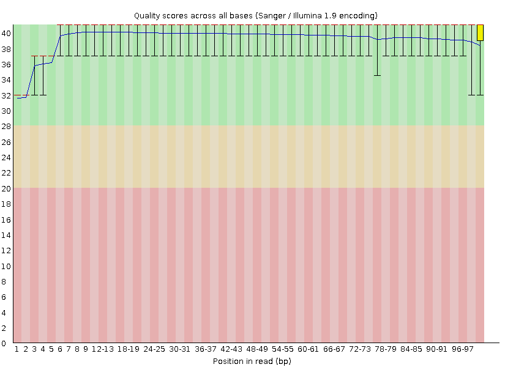

FASTQC graph showing N distribution of 8_2F_fox_S7_L008_R1_001.

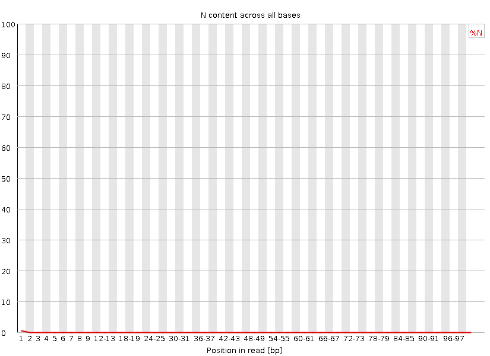

FASTQC graph showing per base sequence quality of 8_2F_fox_S7_L008_R2_001.

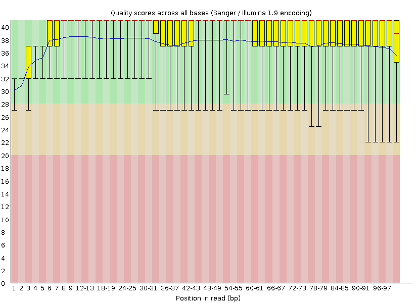

FASTQC graph showing N distribution of 8_2F_fox_S7_L008_R2_001.

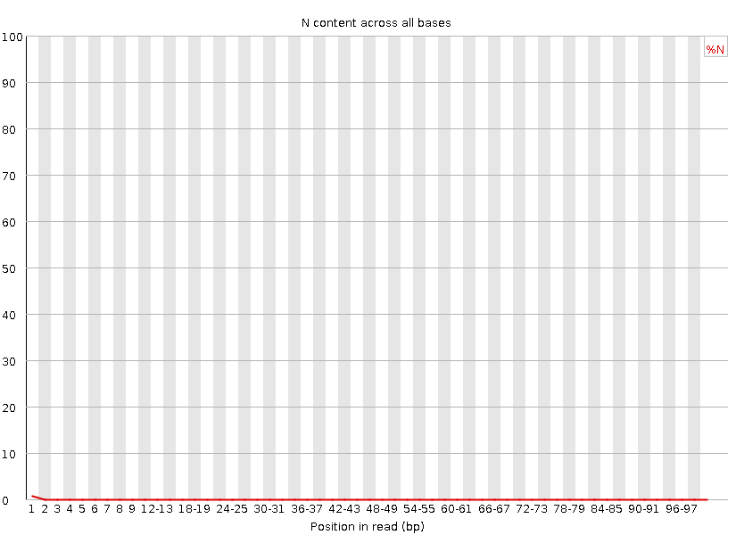

FASTQC graph showing per base sequence quality of 14_3B_control_S10_L008_R1_001.

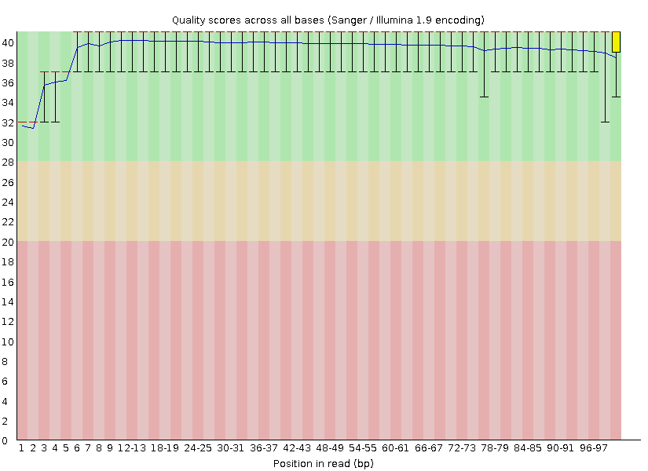

FASTQC graph showing N distribution of 14_3B_control_S10_L008_R1_001.

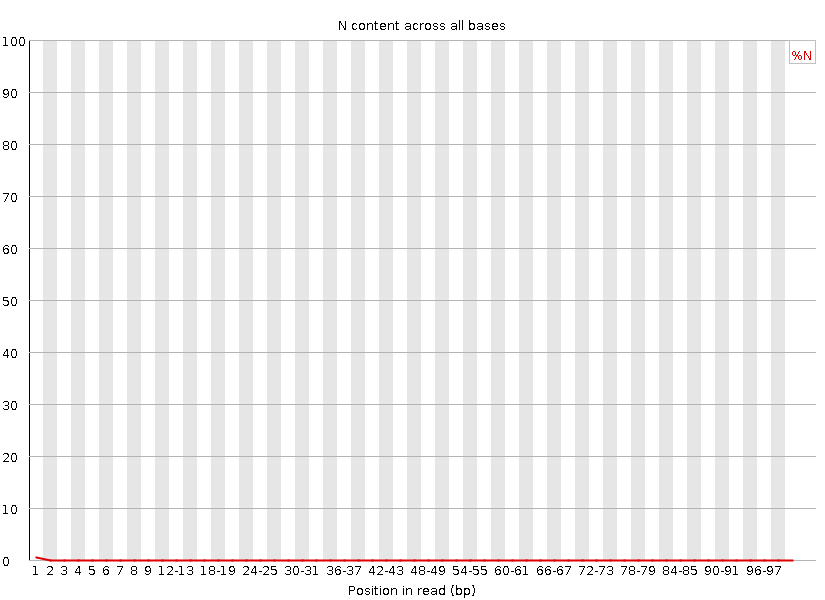

FASTQC graph showing per base sequence quality of 14_3B_control_S10_L008_R2_001.

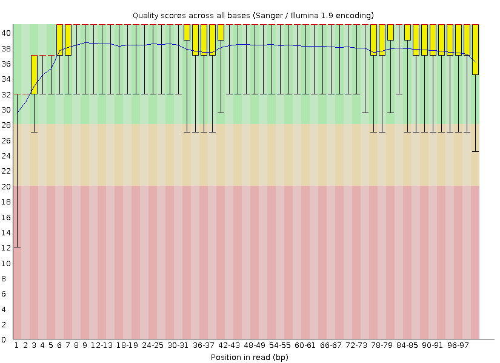

FASTQC graph showing N distribution of 14_3B_control_S10_L008_R2_001.

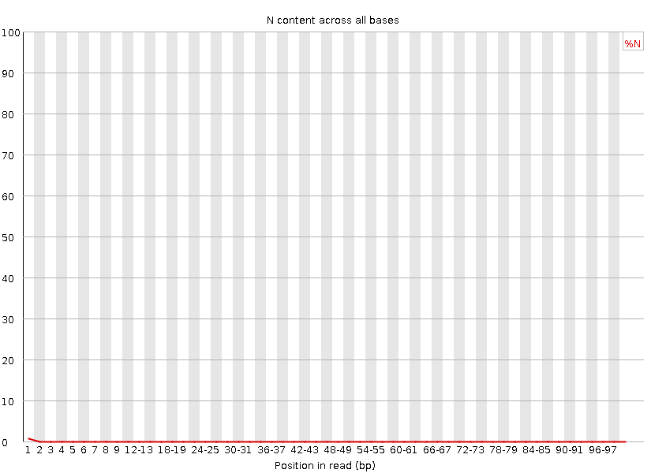

**Part 2: Adapter trimming comparison**

Cutadapt: -Below are my commands using cutadapt (Version 3.4, Build py39h38f01e4_1) to trim adapter sequences.

```bash
#for 8_2F_fox_S7_L008 files
cutadapt -b AGATCGGAAGAGCACACGTCTGAACTCCAGTCA -B AGATCGGAAGAGCGTCGTGTAGGGAAAGAGTGT -o /home/ndr/bgmp/bioinfo/Bi623/Assignments/QAA/cutadapt/cut_8_2F_fox_S7_L008_R1_001_fastqc.fq -p /home/ndr/bgmp/bioinfo/Bi623/Assignments/QAA/cutadapt/cut_8_2F_fox_S7_L008_R2_001_fastqc.fq /projects/bgmp/shared/2017_sequencing/demultiplexed/8_2F_fox_S7_L008_R1_001.fastq.gz /projects/bgmp/shared/2017_sequencing/demultiplexed/8_2F_fox_S7_L008_R2_001.fastq.gz
```

=== Summary ===

Total read pairs processed: 36,482,601  
Read 1 with adapter: 2,778,535 (7.6%)  
Read 2 with adapter: 2,877,524 (7.9%)  
Pairs written (passing filters): 36,482,601 (100.0%)

Total basepairs processed: 7,369,485,402 bp  
Read 1: 3,684,742,701 bp  
Read 2: 3,684,742,701 bp  
Total written (filtered): 7,311,697,532 bp (99.2%)  
Read 1: 3,656,033,391 bp  
Read 2: 3,655,664,141 bp

```bash
#for 14_3B_control_S10_L008 files
cutadapt -b AGATCGGAAGAGCACACGTCTGAACTCCAGTCA -B AGATCGGAAGAGCGTCGTGTAGGGAAAGAGTGT -o /home/ndr/bgmp/bioinfo/Bi623/Assignments/QAA/cutadapt/cut_14_3B_control_S10_L008_R1_001_fastqc.zip -p /home/ndr/bgmp/bioinfo/Bi623/Assignments/QAA/cutadapt/cut_14_3B_control_S10_L008_R2_001_fastqc.zip /projects/bgmp/shared/2017_sequencing/demultiplexed/14_3B_control_S10_L008_R1_001.fastq.gz /projects/bgmp/shared/2017_sequencing/demultiplexed/14_3B_control_S10_L008_R2_001.fastq.gz
```

=== Summary ===

Total read pairs processed: 4,440,378  
Read 1 with adapter: 336,435 (7.6%)  
Read 2 with adapter: 357,683 (8.1%)  
Pairs written (passing filters): 4,440,378 (100.0%)

Total basepairs processed: 896,956,356 bp  
Read 1: 448,478,178 bp  
Read 2: 448,478,178 bp  
Total written (filtered): 888,894,806 bp (99.1%)  
Read 1: 444,481,143 bp  
Read 2: 444,413,663 bp

Trimmomatic:  
-Below are my commands using Trimmomatic (Version 0.39, Build hdfd78af_2) to quality trim the reads.  
Settings:

LEADING: quality of 3  
TRAILING: quality of 3  
SLIDING WINDOW: window size of 5 and required quality of 15  
MINLENGTH: 35 bases

```bash
#for 8_2F_fox_S7_L008 samples
trimmomatic PE -phred33 cut_8_2F_fox_S7_L008_R1_001_fastqc.fq cut_8_2F_fox_S7_L008_R2_001_fastqc.fq -baseout 8_2F_fox_S7_L008_trimmed.fq LEADING:3 TRAILING:3 SLIDINGWINDOW:5:15 MINLEN:35
TrimmomaticPE: Started with arguments:
 -phred33 cut_8_2F_fox_S7_L008_R1_001_fastqc.fq cut_8_2F_fox_S7_L008_R2_001_fastqc.fq -baseout 8_2F_fox_S7_L008_trimmed.fq LEADING:3 TRAILING:3 SLIDINGWINDOW:5:15 MINLEN:35

Using templated Output files: 8_2F_fox_S7_L008_trimmed_1P.fq 8_2F_fox_S7_L008_trimmed_1U.fq 8_2F_fox_S7_L008_trimmed_2P.fq 8_2F_fox_S7_L008_trimmed_2U.fq
Input Read Pairs: 36482601 Both Surviving: 34798153 (95.38%) Forward Only Surviving: 1631451 (4.47%) Reverse Only Surviving: 28693 (0.08%) Dropped: 24304 (0.07%)
TrimmomaticPE: Completed successfully

#For cut_14_3B_control_S10_L008
trimmomatic PE -phred33 cut_14_3B_control_S10_L008_R1_001_fastqc.fq cut_14_3B_control_S10_L008_R2_001_fastqc.fq -baseout 14_3B_control_S10_L008_trimmed.fq LEADING:3 TRAILING:3 SLIDINGWINDOW:5:15 MINLEN:35

TrimmomaticPE: Started with arguments:
 -phred33 cut_14_3B_control_S10_L008_R1_001_fastqc.fq cut_14_3B_control_S10_L008_R2_001_fastqc.fq -baseout 14_3B_control_S10_L008_trimmed.fq LEADING:3 TRAILING:3 SLIDINGWINDOW:5:15 MINLEN:35

Using templated Output files: 14_3B_control_S10_L008_trimmed_1P.fq 14_3B_control_S10_L008_trimmed_1U.fq 14_3B_control_S10_L008_trimmed_2P.fq 14_3B_control_S10_L008_trimmed_2U.fq
Input Read Pairs: 4440378 Both Surviving: 4251493 (95.75%) Forward Only Surviving: 182469 (4.11%) Reverse Only Surviving: 3291 (0.07%) Dropped: 3125 (0.07%)
TrimmomaticPE: Completed successfully
```

```python
#!/usr/bin/env python

import gzip, matplotlib.pyplot as plt

#test files with first 50 lines from their respective parent files
fox_test1 = "/home/ndr/bgmp/bioinfo/Bi623/Assignments/QAA/fox_r1_test.fq.gz"
#I dramatically shortened the reads in fox_test2 to be sure the colors and legend og my graphs properly matched the data
fox_test2 = "/home/ndr/bgmp/bioinfo/Bi623/Assignments/QAA/fox_r2_test.fq.gz"
control_test1 = "/home/ndr/bgmp/bioinfo/Bi623/Assignments/QAA/control_r1_test.fq.gz"
control_test2 = "/home/ndr/bgmp/bioinfo/Bi623/Assignments/QAA/control_r2_test.fq.gz"

fox_r1 = "/home/ndr/bgmp/bioinfo/Bi623/Assignments/QAA/8_2F_fox_S7_L008_trimmed_1P.fq.gz"
fox_r2 = "/home/ndr/bgmp/bioinfo/Bi623/Assignments/QAA/8_2F_fox_S7_L008_trimmed_2P.fq.gz"
control_r1 = "/home/ndr/bgmp/bioinfo/Bi623/Assignments/QAA/14_3B_control_S10_L008_trimmed_1P.fq.gz"
control_r2 = "/home/ndr/bgmp/bioinfo/Bi623/Assignments/QAA/14_3B_control_S10_L008_trimmed_2P.fq.gz"

#initialize dictionary where keys = length of read and values = freequency of reads of key length
fox_r1_len_dict =  {}
#create keys for range of read lengths
for x in range(1, 103):
    fox_r1_len_dict[x] = 0

fox_r2_len_dict = {}
for x in range(1, 103):
    fox_r2_len_dict[x] = 0

control_r1_len_dict = {}
for x in range(1, 103):
    control_r1_len_dict[x] = 0

control_r2_len_dict = {}
for x in range(1, 103):
    control_r2_len_dict[x] = 0

#create length:frequency dictionary from 8_2F_fox_S7_L008_trimmed_1P.fq.gz
with gzip.open (fox_r1, "r") as fh:
    num_lines = 0
    for line in fh:
        num_lines += 1
        if num_lines % 4 == 2:
            line = line.decode('UTF-8')
            for key, value in fox_r1_len_dict.items():
                if len(line) == key:
                    fox_r1_len_dict[key] += 1

#create length:frequency dictionary from 8_2F_fox_S7_L008_trimmed_2P.fq.gz
with gzip.open (fox_r2, "r") as fh:
    num_lines = 0
    for line in fh:
        num_lines += 1
        if num_lines % 4 == 2:
            line = line.decode('UTF-8')
            for key, value in fox_r2_len_dict.items():
                if len(line) == key:
                    fox_r2_len_dict[key] += 1

#create length:frequency dictionary from 14_3B_control_S10_L008_trimmed_1P.fq.gz
with gzip.open (control_r1, "r") as fh:
    num_lines = 0
    for line in fh:
        num_lines += 1
        if num_lines % 4 == 2:
            line = line.decode('UTF-8')
            for key, value in control_r1_len_dict.items():
                if len(line) == key:
                    control_r1_len_dict[key] += 1

#create length:frequency dictionary from 14_3B_control_S10_L008_trimmed_2P.fq.gz
with gzip.open (control_r2, "r") as fh:
    num_lines = 0
    for line in fh:
        num_lines += 1
        if num_lines % 4 == 2:
            line = line.decode('UTF-8')
            for key, value in control_r2_len_dict.items():
                if len(line) == key:
                    control_r2_len_dict[key] += 1

#graphing 8_2F_fox_S7_L008 reads
plt.figure()
plt.bar(*zip(*fox_r1_len_dict.items()), color='blue', alpha=0.5)
plt.bar(*zip(*fox_r2_len_dict.items()), color='red', alpha=0.5)
plt.title("Read Length Distribution of Trimmed 8_2F_fox_S7_L008 Reads")
plt.xlabel("Read Length")
plt.yscale("log")
plt.ylabel("log Frequency")
plt.legend(["Read 1", "Read 2"])
plt.savefig("8_2F_fox_S7_L008.png")

#graphing 14_3B_control_S10_L008 reads
plt.figure()
plt.bar(*zip(*control_r1_len_dict.items()), color='blue', alpha=0.5)
plt.bar(*zip(*control_r2_len_dict.items()), color='red', alpha=0.5)
plt.title("Read Length Distribution of Trimmed 14_3B_control_S10_L008 Reads")
plt.xlabel("Read Length")
plt.yscale("log")
plt.ylabel("log Frequency")
plt.legend(["Read 1", "Read 2"])
plt.savefig("14_3B_control_S10_L008.png")
```

Below are the plots for both samples, and it appears Read 2 is trimmed more than Read 1 in both sets of reads.

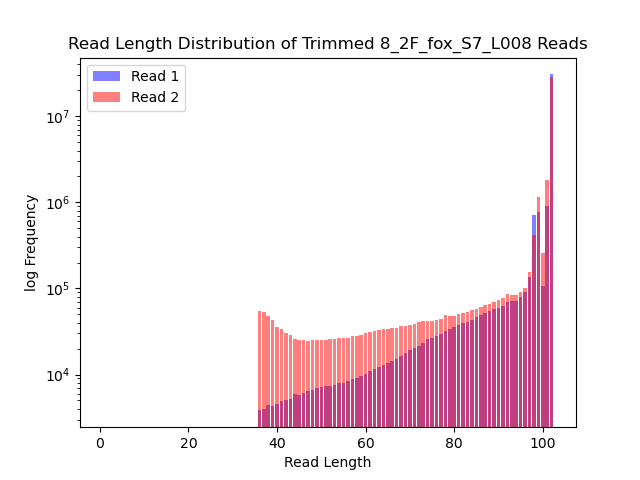

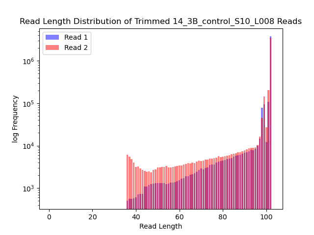

**Part 3: Alignment and strand-specificity**

In my QAA environment, I installed:

-star (Version 2.7.9a, Build h9ee0642_0)  
-numpy (Version 1.21.2, Build py39hdbf815f_0)  
-pysam (Version 0.16.0.1, Build py39h051187c_3)  
-matplotlib (Version 3.4.3, Build py39hf3d152e_0)

Then used pip to install HTseq (Version 0.13.5, Build pypi_0)

My mouse genome fasta file from Ensemble release 104: Mus_musculus.GRCm39.dna.primary_assembly.fa  
My mouse gtf file: Mus_musculus.GRCm39.104.gtf

Below is the Talapus batch script to create an alignment database. File named QAA_database.sh.

```bash
#!/bin/bash

#SBATCH --account=bgmp
#SBATCH --partition=bgmp
#SBATCH --job-name=QAA_DB
#SBATCH --cpus-per-task=8
#SBATCH --nodes=1
#SBATCH --time=10:00:00

conda activate QAA

genome_dir="/home/ndr/bgmp/bioinfo/Bi623/Assignments/QAA/mus_musculus.GRCm39.dna.ens104.STAR_2.7.9a"
genome_ff="/home/ndr/bgmp/bioinfo/Bi623/Assignments/QAA/mus_musculus.GRCm39.dna.ens104.STAR_2.7.9a/Mus_musculus.GRCm39.dna.primary_assembly.fa"
genome_gtf="/home/ndr/bgmp/bioinfo/Bi623/Assignments/QAA/mus_musculus.GRCm39.dna.ens104.STAR_2.7.9a/Mus_musculus.GRCm39.104.gtf"

/usr/bin/time -v STAR --runMode genomeGenerate --runThreadN 8 --genomeDir $genome_dir --genomeFastaFiles $genome_ff --sjdbGTFfile $genome_gtf
```

Below is the Talapus batch script used to align my 14_3B_control_S10_L008 reads to the mouse genomic database. I only changed read1, read2, and outFileNamePrefix for my fox_S7_L008 samples so I didn’t include them here. File named QAA_align.sh.

```bash
#!/bin/bash

#SBATCH --account=bgmp
#SBATCH --partition=bgmp
#SBATCH --job-name=QAA_align_14_3B_control_S10
#SBATCH --cpus-per-task=8
#SBATCH --nodes=1
#SBATCH --time=01:00:00

conda activate QAA

genome_file="/projects/bgmp/ndr/bioinfo/Bi623/Assignments/QAA/mus_musculus.GRCm39.dna.ens104.STAR_2.7.9a/Mus_musculus.GRCm39.dna.primary_assembly.fa.gz"
genome_dir="/projects/bgmp/ndr/bioinfo/Bi623/Assignments/QAA/mus_musculus.GRCm39.dna.ens104.STAR_2.7.9a"
genome_gtf="/projects/bgmp/ndr/bioinfo/Bi623/Assignments/QAA/mus_musculus.GRCm39.dna.ens104.STAR_2.7.9a/Mus_musculus.GRCm39.104.gtf"
read1="/projects/bgmp/ndr/bioinfo/Bi623/Assignments/QAA/14_3B_control_S10_L008_trimmed_1P.fq.gz"
read2="/projects/bgmp/ndr/bioinfo/Bi623/Assignments/QAA/14_3B_control_S10_L008_trimmed_2P.fq.gz"

/usr/bin/time -v STAR --runThreadN 8 --runMode alignReads --outFilterMultimapNmax 3 --alignIntronMax 1000000 \
--outSAMunmapped Within KeepPairs \
--alignMatesGapMax 1000000 --readFilesCommand zcat \
--readFilesIn $read1 $read2 \
--genomeDir $genome_dir \
--outFileNamePrefix 14_3B_control_S10_L008
```

To count mapped and unmapped reads, I updated my script from PS8, shown below.

```python
#!/usr/bin/env python

import argparse

def get_args():
    parser = argparse.ArgumentParser(description="A program to normalize kmer data")
    parser.add_argument("-f", "--input_filename", help="your filename", required = True)
    parser.add_argument("-o", "--output_filename", help="your filename", required = True)

    return parser.parse_args()

args = get_args()
input_file = args.input_filename
output_file = args.output_filename

mapped_count = 0
unmapped_count = 0

with open (input_file, "r") as fh:
    while True:
        new_line = fh.readline()
        if new_line == "":
            break
        if new_line[0] == "@":
            continue
        else:
            name = new_line.split()[0]     #gives us QNAME in SAM file
            flag = new_line.split()[1]     #gives us FLAG in SAM file
        if(int(flag) & 4) != 4 and (int(flag) & 256) == 0:     #need 256 bit == 0
            mapped_count += 1
        elif (int(flag) & 4) == 4 and (int(flag) & 256) == 0:
            unmapped_count += 1      #ticks up unmapped_count for ALL unmapped alignments

total = mapped_count + unmapped_count

with open (output_file, "w") as fout:
    fout.write(f'Input file: {input_file}\n')
    fout.write(f'Mapped: {mapped_count}\nUnmapped: {unmapped_count}\nTotal: {total}')
```

Results:

8_2F_fox_S7_L008 contained:  
-Mapped: 67,048,088  
-Unmapped: 2,548,218  
-Total: 69,596,306

14_3B_control_S10_L008 contained:  
-Mapped: 8,310,327  
-Unmapped: 192,659  
-Total: 8,502,986

I then used HTSeq to count reads that mapped to features. The HTSeq documentation said either GTF or GFF files containing the features could be used, so I used my previously mentioned mouse GTF file. The HTSeq documentation also suggested we use samtools to sort the file by name before counting, code below.

```bash
samtools sort -n 8_2F_fox_S7_L008Aligned.out.sam > sorted_8_2F_fox_S7_L008Aligned.out.sam
samtools sort -n 14_3B_control_S10_L008Aligned.out.sam > sorted_14_3B_control_S10_L008Aligned.out.sam
```

I ran HTSeq-count on the sorted files, changing only the stranded setting and keeping everything else on default.

```bash
#8_2F_fox_S7_L008, stranded=yes
htseq-count --stranded=yes sorted_14_3B_control_S10_L008Aligned.out.sam/home/ndr/bgmp/bioinfo/Bi623/Assignments/QAA/mus_musculus.GRCm39.dna.ens104.STAR_2.7.9a/Mus_musculus.GRCm39.104.gtf > nsort_htseq_yes_strand_counted_8_2F_fox_S7_L008Aligned.txt

#8_2F_fox_S7_L008, stranded=no
htseq-count --stranded=no sorted_14_3B_control_S10_L008Aligned.out.sam/home/ndr/bgmp/bioinfo/Bi623/Assignments/QAA/mus_musculus.GRCm39.dna.ens104.STAR_2.7.9a/Mus_musculus.GRCm39.104.gtf > nsort_htseq_no_strand_counted_8_2F_fox_S7_L008Aligned.txt

#14_3B_control_S10_L008, stranded=yes
htseq-count --stranded=yes sorted_14_3B_control_S10_L008Aligned.out.sam/home/ndr/bgmp/bioinfo/Bi623/Assignments/QAA/mus_musculus.GRCm39.dna.ens104.STAR_2.7.9a/Mus_musculus.GRCm39.104.gtf > nsort_htseq_counted_yes_strand_14_3B_control_S10_L008Aligned.txt

#14_3B_control_S10_L008, stranded=no
htseq-count --stranded=no sorted_14_3B_control_S10_L008Aligned.out.sam/home/ndr/bgmp/bioinfo/Bi623/Assignments/QAA/mus_musculus.GRCm39.dna.ens104.STAR_2.7.9a/Mus_musculus.GRCm39.104.gtf > nsort_htseq_counted_no_strand_sorted_14_3B_control_S10_L008Aligned.txt
```

Summarized Results:  
8_2F_fox_S7_L008, stranded=yes  
__no_feature 30,648,212  
__ambiguous 26,177  
__too_low_aQual 61,546  
__not_aligned 1,241,080  
__alignment_not_unique 1,587,953  
__34,798,153 alignment pairs processed

8_2F_fox_S7_L008, stranded=no  
__no_feature 3,148,132  
__ambiguous 1,554,869  
__too_low_aQual 61,546  
__not_aligned 1,241,080  
__alignment_not_unique 1,587,953  
__34,798,153 alignment pairs processed

14_3B_control_S10_L008, stranded=yes  
__no_feature 3,806,291  
__ambiguous 3,326  
__too_low_aQual 6,265  
__not_aligned 92,990  
__alignment_not_unique 181,967  
4,251,493 alignment pairs processed

14_3B_control_S10_L008, stranded=no  
__no_feature 207,859  
__ambiguous 209,168  
__too_low_aQual 6,265  
__not_aligned 92,990  
__alignment_not_unique 181,967  
__4,251,493 alignment pairs processed

Discussion:  
Fox: 0.17% low quality, 3.6% not aligned, 4.6% alignment not unique, 96.3% mapped  
Control: 0.15% low quality, 2.2% not aligned, 4.3% alignment not unique, 97.8% mapped

Fox stranded=yes: 88% no_feature, 0.08% ambiguous  
Fox stranded=no: 9.0% no_feature, 4.5% ambiguous

Control stranded=yes: 90% no_feature, 0.08% ambiguous  
Control stranded=no: 4.9% no_feature, 4.9% ambiguous

The data are not strand-specific. When using HTSeq stranded=yes, both the Fox and Control have an overwhelming majority (88% and 90%, respectively) of reads that don’t map to a feature. For paired-end data, stranded=yes requires R1 to have R2 mapped to the opposite strand which occurs in strand-specific RNA-seq. In strand non-specific RNA-seq, the orientation of the original transcript is unknown, so stranded=no doesn’t factor this in and a read will map to a feature regardless of R2. When I ran HTSeq with stranded=no, I saw only 9.0% of the Fox reads 4.9% of the Control reads fail to map, suggesting the library is from a strand non-specific RNAseq experiment.